# A3: SPL Library Checkouts

### Introduction

The data that I will be using is from the Seattle Public Library and it consists of all material checked out between 2017 to 2023. I chose this data set because I wanted to see how often people were checking out material that were not books.

### Summary Information

I calculated 5 values in my summary information script. The first value was to see the average number of checkouts for each item. While there is 27 items, I decided to focus on the top 5 things I would checkout from the library. The list consists of Ebooks, Books, Movie, Comic, and Audio book. The average checkout for Ebooks was 25.1, Books was 20.9, Movies was 18.3, Comics was 15.8, Audio books was 25.3. The next value was the highest checkout month for a book titled “Normal people” and the highest month was June with 4903 checkouts. The third value is the year with the most checkouts for ebooks. This was interesting because it was in 2020 with 4903 checkouts. This was during the start of the pandemic. Next, I was wondering how the amount of print book checkouts changed over the years. It shows a trend of an increase each year with a boost during the pandemic. Lastly, I was curious on how many video disc’s were being checkedout in 2023. In 2017 there were roughly 450 and in 2023 there were 175. With only a couple months into 2023, I find that very surprising.

### The Dataset

- The data is provided by The Seattle Public Library.
- There are parameters such as, whether its physical or digital, type of checkout, material, checkout year and month, Title, ISBN, creator, subject, publisher, and publication year.
- The data is collected by Seattle Public Libraries checkout system.
- All sorts of reasons but it seems to be the database for checkouts by Seattle Public Library which would be recorded either way. It could also benefit the library to keep a record of these to understand trends.
- I’m not really sure of any ethical questions because this data is anonymous. I can figure out trends of what people are interested in reading during certain months but that is all.
- There are a lot of limitations because I can only do so much with this data. I can understand trends of when people wanted to start reading, what genres are more prevalent or why people are using the library. But other than that there are only small niche things I can use this data to look at. This is also perfectly fine as this data is solely on what is being checked out by the library. One of the challenges I noticed was anything that wasn’t a form of a book, movie, or song/music was put into a category called “mixed”. This was really hard to figure out what was actually in there and I wasn’t able to see a trend. It would be interesting to figure out the months when computers were checked out the most. Another limitation was that there were many duplicates but R studio suggested that they weren’t. It was a hard work around but there are many items that have an extra comma which skews the data as I would not have noticed it.

### Digital Entertainment Checkouts per Year

I included this chart because I was interested in seeing these forms of entertainment progressed over the years. The data starts at 2017 and ends in 2023. What we can see is that movies and songs stopped being checked out after 2018. This makes sense as Netflix and other streaming platforms grew exceptionally. What is interesting though is that music was still being checked out regularly but has died down significantly. Audio books have shown a strong trends upwards and Ebook’s are slightly more popular now.

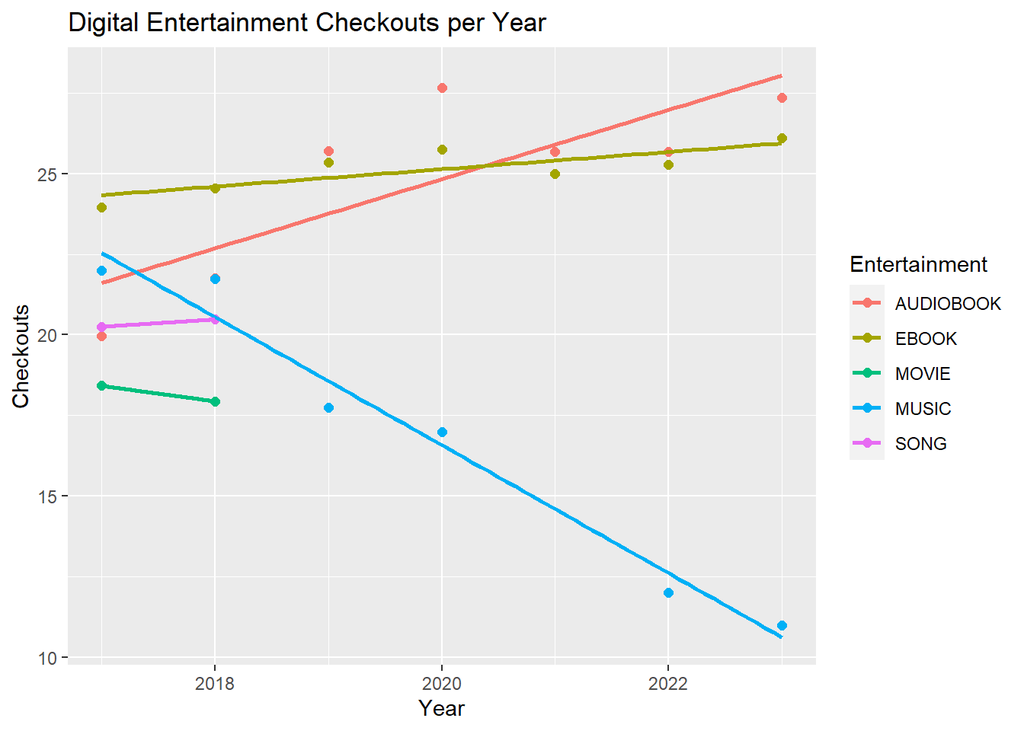

### Average Book Checkouts By Month Betwen 2017 and 2023

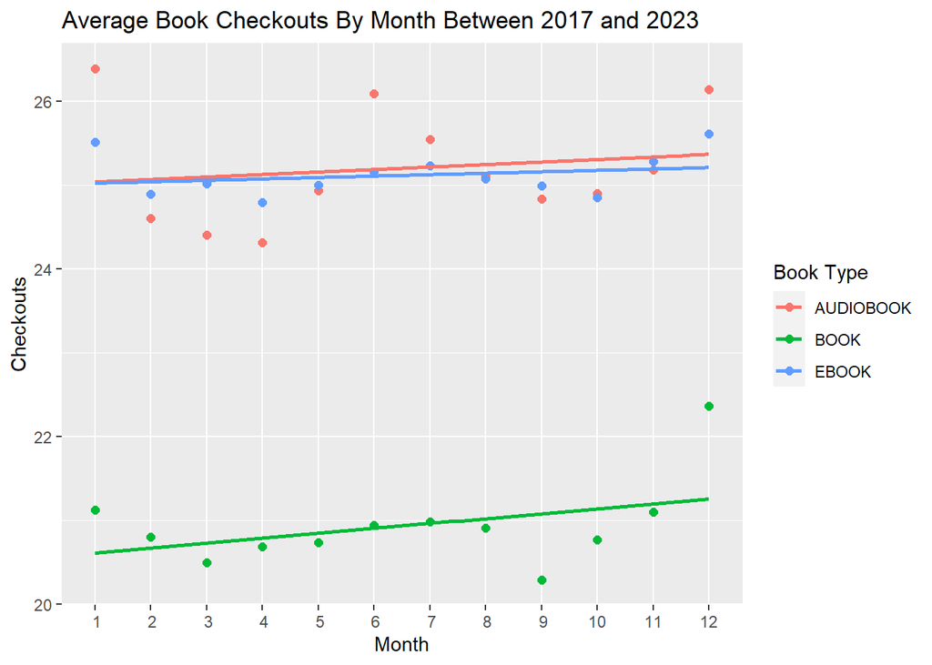

### Top 5 Publishers of 2022

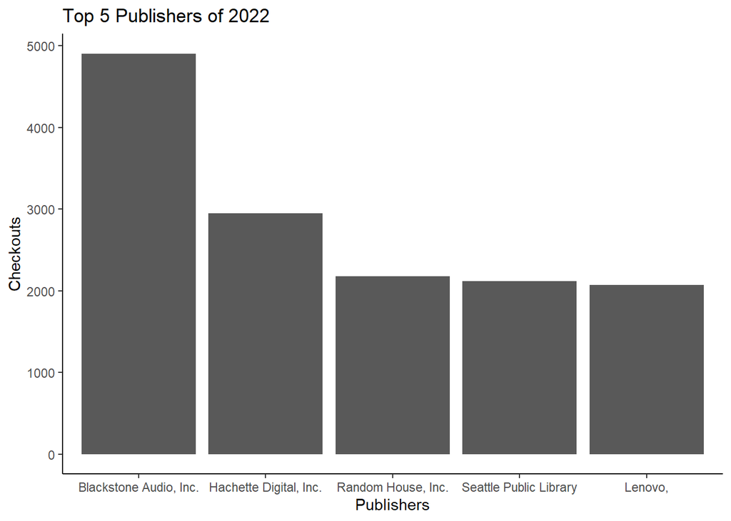